# March_6_Pengs_Exploratory_Data_Checklist

Candy Boatwright

2024-03-02

Peng’s Checklist:

Step 1: Formulate your question

> CREATE A BASELINE OF DATA: Chart the population of South Carolina from 1800-1900 in order to create a baseline of population growth/decline as a result of the cotton Panic of 1819, the westward exodus of planters prior to the end of the Civil War. REGIONAL COMPARISONS: Is it possible to demostrate that through state population data that South Carolina was harder pressed in the cotton panic/federal tariffs and that it caused a westward exodus? Does the west see a significant population increase during this time? Do any other southern states experience similar trends? Any experience vastly different population growth/decline during that same period? NATIONAL COMPARISON: How do southern population trends compare to the north during the same time period?

Step 2: Read your data

```r
library(DigitalMethodsData)
data("statepopulations")
```

Step 3: Check the packaging

```r
library(DigitalMethodsData)
library(tidyverse)
library(dplyr)
data("statepopulations")

nrow(statepopulations)
```

```
## [1] 84
```

```r
ncol(statepopulations)
```

```
## [1] 28
```

Step 4: Run str()

```r
str(statepopulations)
```

```
## 'data.frame':    84 obs. of  28 variables:
##  $ GISJOIN: chr  "G010" "G020" "G025" "G040" ...
##  $ STATE  : chr  "Alabama" "Alaska" "Alaska Territory" "Arizona" ...
##  $ STATEFP: int  1 2 NA 4 NA 5 NA 6 8 NA ...
##  $ STATENH: int  10 20 25 40 45 50 55 60 80 85 ...
##  $ X1790  : int  NA NA NA NA NA NA NA NA NA NA ...
##  $ X1800  : int  NA NA NA NA NA NA NA NA NA NA ...
##  $ X1810  : int  NA NA NA NA NA NA NA NA NA NA ...
##  $ X1820  : int  127901 NA NA NA NA NA 14273 NA NA NA ...
##  $ X1830  : int  309527 NA NA NA NA NA 30388 NA NA NA ...
##  $ X1840  : int  590756 NA NA NA NA 97574 NA NA NA NA ...
##  $ X1850  : int  771623 NA NA NA NA 209897 NA 92597 NA NA ...
##  $ X1860  : int  964201 NA NA NA NA 435450 NA 379994 NA 34277 ...
##  $ X1870  : int  996992 NA NA NA 9658 484471 NA 560247 NA 39864 ...
##  $ X1880  : int  1262505 NA 33426 NA 40440 802525 NA 864694 194327 NA ...
##  $ X1890  : int  1513017 NA 32052 NA 59620 1128179 NA 1208130 412198 NA ...
##  $ X1900  : int  1828697 NA 63592 NA 122931 1311564 NA 1485053 539700 NA ...
##  $ X1910  : int  2138093 NA 64356 NA 204354 1574449 NA 2377549 799024 NA ...
##  $ X1920  : int  2348174 NA 55036 334162 NA 1752204 NA 3426861 939629 NA ...
##  $ X1930  : int  2646248 NA 59278 435573 NA 1854482 NA 5677251 1035791 NA ...
##  $ X1940  : int  2832961 NA 72524 499261 NA 1949387 NA 6907387 1123296 NA ...
##  $ X1950  : int  3061743 NA 128643 749587 NA 1909511 NA 10586224 1325089 NA ...
##  $ X1960  : int  3266740 226167 NA 1302161 NA 1786272 NA 15717204 1753947 NA ...
##  $ X1970  : int  3444165 300382 NA 1770900 NA 1923295 NA 19953134 2207259 NA ...
##  $ X1980  : int  3893888 401851 NA 2718215 NA 2286435 NA 23667902 2889964 NA ...
##  $ X1990  : int  4040587 550043 NA 3665228 NA 2350725 NA 29760021 3294394 NA ...
##  $ X2000  : int  4447100 626932 NA 5130632 NA 2673400 NA 33871648 4301261 NA ...
##  $ X2010  : int  4779736 710231 NA 6392017 NA 2915918 NA 37253956 5029196 NA ...
##  $ X2020  : int  5024279 733391 NA 7151502 NA 3011524 NA 39538223 5773714 NA ...
```

```r
#shows that all variables(columns) that contain NA are int
```

Step 5: Look at the top and bottom of your data

```r
head(statepopulations[, c(1:5, 28)])
```

```
##   GISJOIN             STATE STATEFP STATENH X1790   X2020
## 1    G010           Alabama       1      10    NA 5024279
## 2    G020            Alaska       2      20    NA  733391
## 3    G025  Alaska Territory      NA      25    NA      NA
## 4    G040           Arizona       4      40    NA 7151502
## 5    G045 Arizona Territory      NA      45    NA      NA
## 6    G050          Arkansas       5      50    NA 3011524
```

```r
tail(statepopulations[, c(1:5, 28)])
```

```
##    GISJOIN                   STATE STATEFP STATENH X1790   X2020
## 79    G550               Wisconsin      55     550    NA 5893718
## 80    G555     Wisconsin Territory      NA     555    NA      NA
## 81    G560                 Wyoming      56     560    NA  576851
## 82    G565       Wyoming Territory      NA     565    NA      NA
## 83    G720             Puerto Rico      72     720    NA 3285874
## 84    G999 Persons in the Military      NA     999    NA      NA
```

Step 6: Check your “n”s

```r
library(dplyr)

#data (statepopulations) %>%  str_detect(replace_na(STATEFP, "NA"))

#filter (statepopulations, STATEFP == is.na) %>%
#    select (STATE, X1790:X2020)

#statepopulations$X1790 %>% replace_na("0")

statepopulations$STATEFP %>% str_detect("NA") #shows that NA is detectable as "NA"; do not understand why I can't filter by "NA" or use the is.na?
```

```
##  [1] FALSE FALSE    NA FALSE    NA FALSE    NA FALSE FALSE    NA FALSE    NA
## [13] FALSE FALSE FALSE    NA FALSE FALSE    NA FALSE    NA FALSE    NA    NA
## [25] FALSE    NA FALSE    NA FALSE    NA FALSE FALSE    NA FALSE FALSE FALSE
## [37] FALSE    NA FALSE    NA FALSE    NA FALSE    NA FALSE    NA FALSE    NA
## [49] FALSE    NA FALSE FALSE FALSE    NA FALSE FALSE FALSE    NA FALSE FALSE
## [61]    NA FALSE    NA    NA FALSE FALSE FALSE FALSE    NA FALSE FALSE FALSE
## [73]    NA FALSE FALSE FALSE    NA FALSE FALSE    NA FALSE    NA FALSE    NA
```

> The previous section was throwing all kinds of errors when I was attempting to knit so I used # to comment it out. The last section I was able to get to run and produce a list of logial returns based on whether it returned NA or not.

Step 7: Validate at least one external data source

> I created another dataset based on data in the South Carolina 1910 Census to compare to the statepopulations dataset

```r
library(readr)

SC.1910.Census.Data <- read_csv("https://docs.google.com/spreadsheets/d/e/2PACX-1vRykQyFdzO3ymKCZ4cXtXmA273iSnAEvcmjm9tdTKEdgXkpmaGSr0p6mYO9shO1GRBBDs5N6TM4LRxU/pub?gid=0&single=true&output=csv", col_types = "iiinn")
print(SC.1910.Census.Data)
```

```
## # A tibble: 13 × 5
##    Census.Year Population Number.Increase.Over.Precedin…¹ Percent.Increase.Ove…²
##          <int>      <int>                           <int>                  <dbl>
##  1        1910    1515400                          175084                   13.1
##  2        1900    1340316                          189167                   16.4
##  3        1890    1151149                          155572                   15.6
##  4        1880     995577                          289971                   41.1
##  5        1870     705606                            1898                    0.3
##  6        1860     703708                           35201                    5.3
##  7        1850     668507                           74109                   12.5
##  8        1840     594398                           13213                    2.3
##  9        1830     581185                           78444                   15.6
## 10        1820     502741                           87626                   21.1
## 11        1810     415115                           69524                   20.1
## 12        1800     345591                           96518                   38.8
## 13        1790     249073                              NA                   NA
## # ℹ abbreviated names: ¹Number.Increase.Over.Preceding.Census,
## #   ²Percent.Increase.Over.Preceding.Census
## # ℹ 1 more variable: Percent.Of.Increase.for.the.United.States <dbl>
```

```r
#p <- problems(SC.1910.Census.Data) showed the columns with decimals were messing up reading as int, changed to n which is human readable number
#p

#Put quotes around Google sheets link, otherwise you spend an hour trying to figure out how to read_csv
```

Step 8: Try the easy solution first

```r
state.pop.longer <- statepopulations %>%
  pivot_longer(!GISJOIN:STATENH, names_to = "year", values_to = "count")

sc.state.pop.longer <- state.pop.longer %>% filter(STATE == "South Carolina") %>% filter(year == "X1790" | year == "X1800" | year == "X1810" | year == "X1820" | year == "X1830"| year == "X1840"| year == "X1850"| year == "X1860"| year == "X1870"| year == "X1880"| year == "X1890")
print (sc.state.pop.longer)
```

```
## # A tibble: 11 × 6
##    GISJOIN STATE          STATEFP STATENH year    count
##    <chr>   <chr>            <int>   <int> <chr>   <int>
##  1 G450    South Carolina      45     450 X1790  249073
##  2 G450    South Carolina      45     450 X1800  345591
##  3 G450    South Carolina      45     450 X1810  415115
##  4 G450    South Carolina      45     450 X1820  502741
##  5 G450    South Carolina      45     450 X1830  581185
##  6 G450    South Carolina      45     450 X1840  594398
##  7 G450    South Carolina      45     450 X1850  668507
##  8 G450    South Carolina      45     450 X1860  703708
##  9 G450    South Carolina      45     450 X1870  705606
## 10 G450    South Carolina      45     450 X1880  995577
## 11 G450    South Carolina      45     450 X1890 1151149
```

```
## `geom_line()`: Each group consists of only one observation.
## ℹ Do you need to adjust the group aesthetic?
```

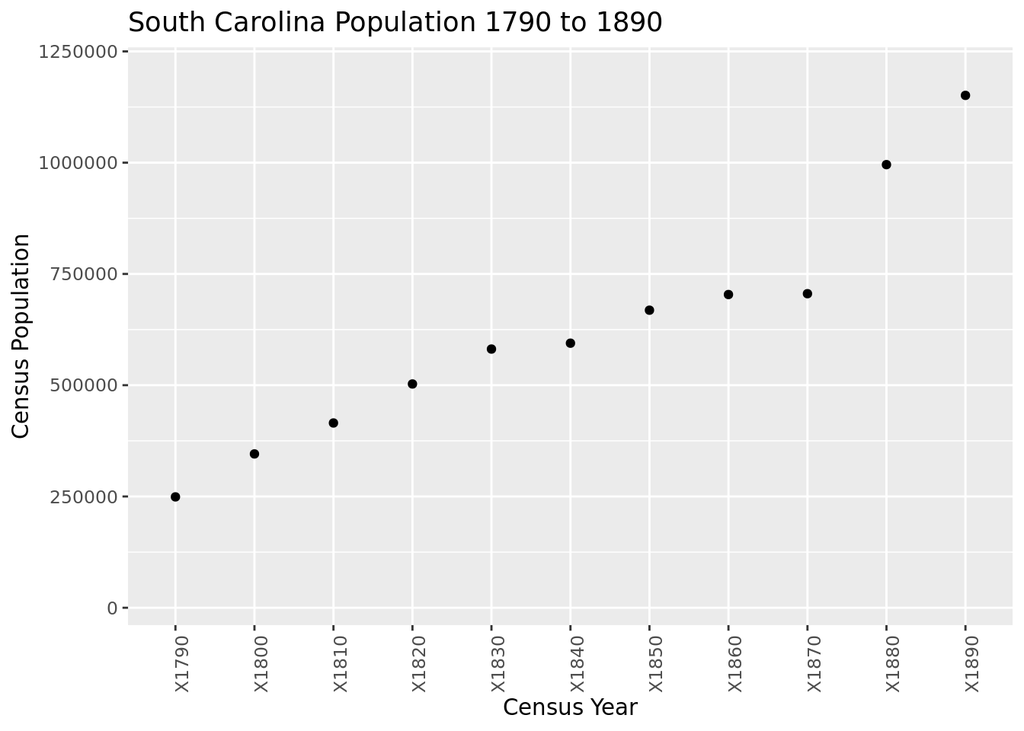

```r
ggplot(sc.state.pop.longer, aes(x = year, y=count, group = year)) + theme(axis.text.x=element_text(angle=90,hjust=1)) + geom_point() + geom_line() + labs(x="Census Year", y="Census Population", title="South Carolina Population 1790 to 1890") +
  scale_y_continuous(limits=c(20000, 1200000))
```

> Base line map of South Carolina’s population through 1890 (end of Reconstruction). Shows stagnent/slow growth from 1820-1870. Not able to get geom_line() to work.

```r
state.pop.longer <- statepopulations %>%
  pivot_longer(!GISJOIN:STATENH, names_to = "year", values_to = "count")

southern.state.pop.longer <- state.pop.longer %>% group_by(STATE) %>% filter(STATE == "South Carolina" | STATE == "North Carolina"| STATE == "Georgia" | STATE == "Virginia" | STATE == "Texas" | STATE == "Arkansas" | STATE == "Louisiana" | STATE == "Tennessee" | STATE == "Mississippi" | STATE == "Alabama" | STATE == "Florida") %>% filter(year == "X1790" | year == "X1800" | year == "X1810" | year == "X1820" | year == "X1830"| year == "X1840"| year == "X1850"| year == "X1860"| year == "X1870"| year == "X1880"| year == "X1890")
print (southern.state.pop.longer)
```

```
## # A tibble: 121 × 6
## # Groups:   STATE [11]
##    GISJOIN STATE   STATEFP STATENH year    count
##    <chr>   <chr>     <int>   <int> <chr>   <int>
##  1 G010    Alabama       1      10 X1790      NA
##  2 G010    Alabama       1      10 X1800      NA
##  3 G010    Alabama       1      10 X1810      NA
##  4 G010    Alabama       1      10 X1820  127901
##  5 G010    Alabama       1      10 X1830  309527
##  6 G010    Alabama       1      10 X1840  590756
##  7 G010    Alabama       1      10 X1850  771623
##  8 G010    Alabama       1      10 X1860  964201
##  9 G010    Alabama       1      10 X1870  996992
## 10 G010    Alabama       1      10 X1880 1262505
## # ℹ 111 more rows
```

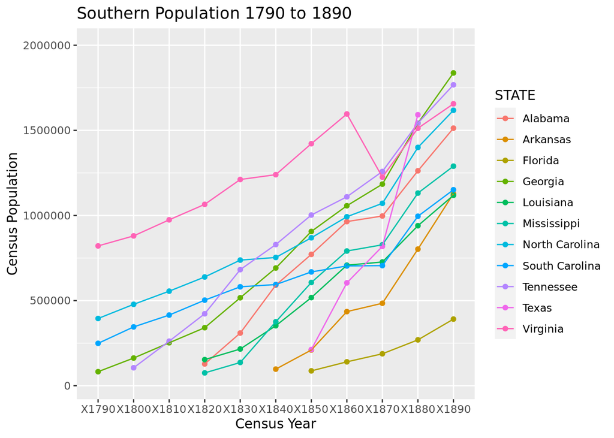

```r
ggplot(southern.state.pop.longer, aes(x = year, y=count, color = STATE, group = STATE)) + geom_point() + geom_line() + labs(x="Census Year", y="Census Population", title="Southern Population 1790 to 1890") +
  scale_y_continuous(limits=c(20000, 2000000))
```

> Shows that North Carolina, South Carolina and Viriginia saw a significant growth stagnation between 1830 and 1840. All other southern states reporting between 1830 and 1840 saw a significant population growth with Alabama and Mississippi showing the largest growth. This would seem to support the idea that many South Carolinians were relocating west during this time, but that a similar situation was occuring in North Carolina and Viriginia. Neither NC or VA saw a Nullification Crisis in early the 1830s, though.

```r
state.pop.longer <- statepopulations %>%
  pivot_longer(!GISJOIN:STATENH, names_to = "year", values_to = "count")

northern.state.pop.longer <- state.pop.longer %>% group_by(STATE) %>% filter(STATE == "Delaware" | STATE == "Pennsylvania"| STATE == "New Jersey" | STATE == "Connecticut" | STATE == "Massachusetts" | STATE == "Maryland" | STATE == "New Hampshire" | STATE == "New York" | STATE == "Rhode Island" | STATE == "Vermont" | STATE == "Maine") %>% filter(year == "X1790" | year == "X1800" | year == "X1810" | year == "X1820" | year == "X1830"| year == "X1840"| year == "X1850"| year == "X1860"| year == "X1870"| year == "X1880"| year == "X1890")
print (northern.state.pop.longer)
```

```
## # A tibble: 121 × 6
## # Groups:   STATE [11]
##    GISJOIN STATE       STATEFP STATENH year   count
##    <chr>   <chr>         <int>   <int> <chr>  <int>
##  1 G090    Connecticut       9      90 X1790 237655
##  2 G090    Connecticut       9      90 X1800 251002
##  3 G090    Connecticut       9      90 X1810 261942
##  4 G090    Connecticut       9      90 X1820 275248
##  5 G090    Connecticut       9      90 X1830 297675
##  6 G090    Connecticut       9      90 X1840 309978
##  7 G090    Connecticut       9      90 X1850 370792
##  8 G090    Connecticut       9      90 X1860 460147
##  9 G090    Connecticut       9      90 X1870 537454
## 10 G090    Connecticut       9      90 X1880 622700
## # ℹ 111 more rows
```

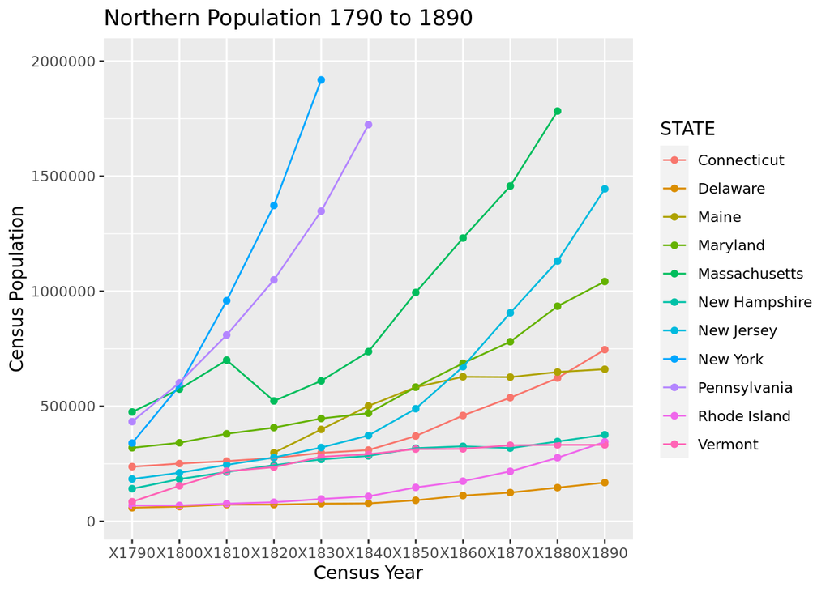

```r
ggplot(northern.state.pop.longer, aes(x = year, y=count, color = STATE, group = STATE)) + geom_point() + geom_line() + labs(x="Census Year", y="Census Population", title="Northern Population 1790 to 1890") +
  scale_y_continuous(limits=c(20000, 2000000))
```

Step 9: Challenge your solution

```r
state.pop.longer <- statepopulations %>%
  pivot_longer(!GISJOIN:STATENH, names_to = "year", values_to = "count")

populations.in.1830.and.1840 <- state.pop.longer %>% filter (year == "X1830" | year == "X1840") %>% filter (count > 0)
print (populations.in.1830.and.1840)
```

```
## # A tibble: 58 × 6
##    GISJOIN STATE                STATEFP STATENH year   count
##    <chr>   <chr>                  <int>   <int> <chr>  <int>
##  1 G010    Alabama                    1      10 X1830 309527
##  2 G010    Alabama                    1      10 X1840 590756
##  3 G050    Arkansas                   5      50 X1840  97574
##  4 G055    Arkansas Territory        NA      55 X1830  30388
##  5 G090    Connecticut                9      90 X1830 297675
##  6 G090    Connecticut                9      90 X1840 309978
##  7 G100    Delaware                  10     100 X1830  76748
##  8 G100    Delaware                  10     100 X1840  78085
##  9 G110    District Of Columbia      11     110 X1830  39834
## 10 G110    District Of Columbia      11     110 X1840  43712
## # ℹ 48 more rows
```

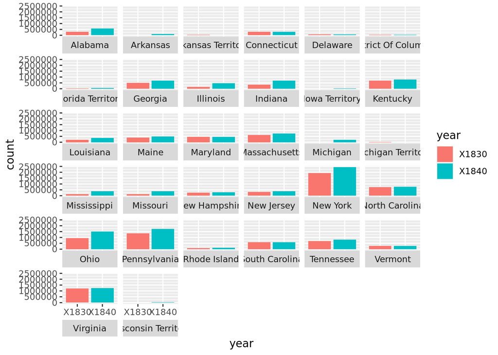

```r
ggplot(populations.in.1830.and.1840, aes(x = year, y = count, fill = year, group = year)) + geom_col() + facet_wrap(~STATE, strip.position = "bottom") + theme(strip.placement = "outside")
```

> Probably not the best visualization because of scale, but does show the states/territories that saw stagnation and which saw growth. Reinforces the challenge to southern thinking that all the northern economies were growing at their expense during the cotton bust/tariff era.

Step 10: Follow up

> What about Kentucky, Ohio, Indiana, Illinois, Missouri, Michigan, Iowa, Wisconsin, California, Minnesota, Oregon, Kansas, Nevada - all admitted before Civil War but not typically identified as Northern or Southern? Also complicated because some were admitted as slave/free state and then either Confederate/Union during Civil War.